# Action Report

### Cleaned Dataset Description

After cleaning the datasets and merging into one dataset, the final dataset consists of 1881 rows and 23 columns, the columns include:

- tweet_id - Unique id for each tweet.
- source - The device the tweet originated from.
- text - The text contained in the tweet.
- expanded_urls - The tweet Url's.
- rating_numerator - The rating numerator out of 10.
- rating_denominator - The rating denominator taken as 10.
- name - The dog name.
- dog_size - The classification of the dogs by size
- date - The date the tweet was made.
- time - The time of the tweet
- jpg_url - The dog image url
- img_num - The image number
- p1 - The algorithm's #1 prediction
- p1_conf - Accuracy confindence for the #1 prediction
- p1_dog - Whether or not the #1 prediction is a breed of dog
- p2 - The algorithm's #2 prediction
- p2_conf -Accuracy confindence for the #2 prediction
- p2_dog - Whether or not the #2 prediction is a breed of dog
- p3 - The algorithm's #3 prediction
- p3_conf - Accuracy confindence for the #3 prediction
- p3_dog - Whether or not the #3 prediction is a breed of dog
- retweet_count - The number of retweets per tweet
- favorite_count - The number of likes per tweet

### Insights

The pie chart below shows that in the tweet data, puppo was the dog_size that most common, and floofer the least common

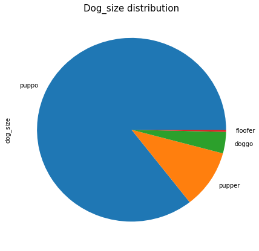

1. Most tweets originated from iphones

From the barchart below, we see that twitter for iphone was source for most of our tweets with over 1750 tweets

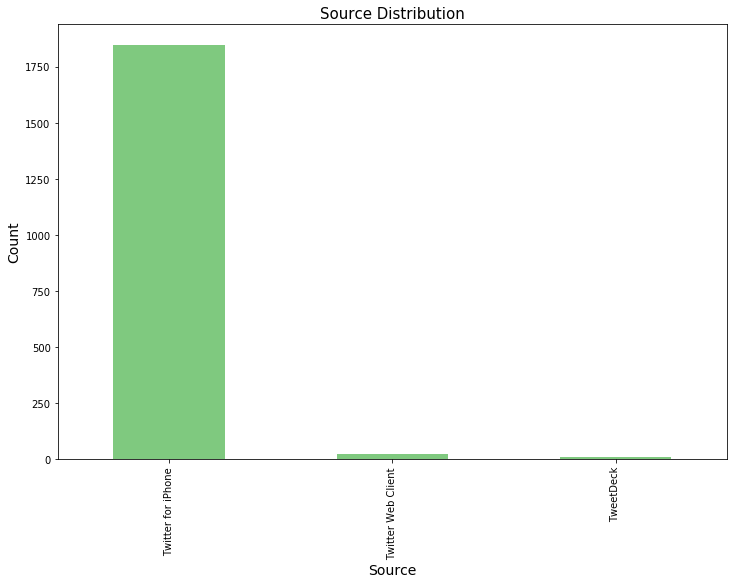

1. Doggo was the dogsize with the most likes

From the bar chart we see that the dog size that recieved the most likes on average was "doggo"

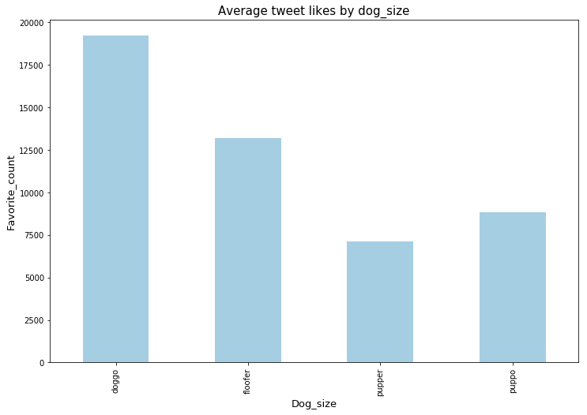

1. For the doggo dog_size most likes came from an iphone source, while pupper had the least likes from iphone source. for the pupper dog_size most likes came from twitter web client source

From the clustered bar chart below we can see that most of the likes for the doggo dogsize originated from the twitter for iphone source and the pupper dogsize had the highest likes from the twitter web client source

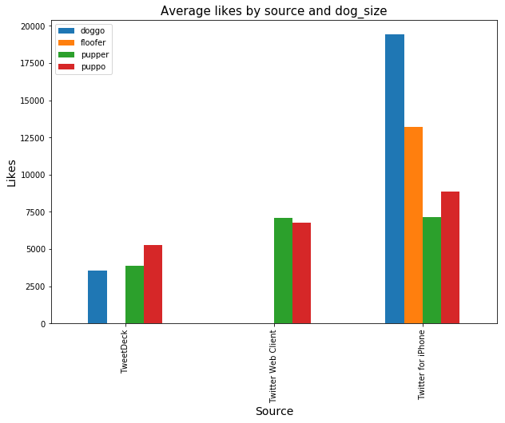

### Interesting things as per findings

It would seem that majority of the followers of the page are iphone users as seen from the data, although we can't really tell if iphone users in the demography the tweets were from are more of dog lovers than opposed to other domestic animals like cats for instance, also why the doggo dogsize is the most liked amongst iphone users could tell us something about iphone users who follow the twitter page.